# Pratical Machine Learning Course Project

Moura

Oct 24, 2015

## OVERVIEW:

The objective of the project is to predict the manner in which the subjects did the exercise, from the “classe” variable. The data is about personal activity collected by the accelerometers from some devices, like Jawbone Up, Nike FuelBand, Fitbit. The data for this project come from this source: http://groupware.les.inf.puc-rio.br/har.

## DATA PROCESSING

```r
library(caret)
library(randomForest)
```

```r
library(rpart)
library(rpart.plot)
library(rattle)
plmTesting = read.csv("pml-testing.csv", na.strings=c("NA","#DIV/0!",""))
plmTraining = read.csv("pml-training.csv",na.strings=c("NA","#DIV/0!",""))
```

First let’s look at the dimension of our data set:

```r
dim(plmTraining)
```

```
## [1] 19622   160
```

```r
dim(plmTesting)
```

```
## [1]  20 160
```

## Data Pre-processing

According to the documentation, the ballance of fields are numeric, so we casted the data into numeric, with the exception to the class column:

```r
for(i in c(8:ncol(plmTraining)-1)){
  plmTraining[,i] = as.numeric(as.character(plmTraining[,i]))
  plmTesting[,i] = as.numeric(as.character(plmTesting[,i]))
}
```

1- First we will delet the first column, which is the ID variable. Then, we will identify the NearZeroVariance variables and exclude them

```r
plmTraining = plmTraining[,-c(1)]
plmTesting = plmTesting[,-c(1)]
NZV = nearZeroVar(plmTraining,saveMetrics=TRUE)
plmTraining = plmTraining[,!NZV$nzv]
plmTesting = plmTesting[,!NZV$nzv]
dim(plmTraining)
```

```
## [1] 19622   123
```

2- Then we will delete the variables that have more than 60% of their values NA’s:

```r
provTraining = plmTraining
provTesting = plmTesting
for(i in 1:length(plmTraining)){
  if(sum(is.na(plmTraining[,i]))/nrow(plmTraining) >= .6){
    for(j in 1:length(provTraining)){
      if(length(grep(names(plmTraining[i]),names(provTraining)[j]) == 1)){
        provTraining = provTraining[,-j]
        provTesting = provTesting[,-j]
      }
    }
  }
}

dim(provTraining)
```

```
## [1] 19622    58
```

```r
dim(provTesting)
```

```
## [1] 20 58
```

```r
plmTraining = provTraining
plmTesting = provTesting
```

As we have a large sample size, we are going to use 60% of the sample for training, 20% for testing and 20% for validating:

```r
set.seed(1234)
inTrain = createDataPartition(plmTraining$classe, p=0.6,list=FALSE)
training = plmTraining[inTrain,]
#This will create another partition of the 40% of the data, 20% testing and 20% validating
totalValidationSet = plmTraining[-inTrain,]
inValidation = createDataPartition(totalValidationSet$classe,p=0.5,list=FALSE)
testing = totalValidationSet[inValidation,]
validating = totalValidationSet[-inValidation,]
rm(totalValidationSet,inValidation)
```

## Selecting model

### Decision Tree

Here we train our model and predict the in-sample error:

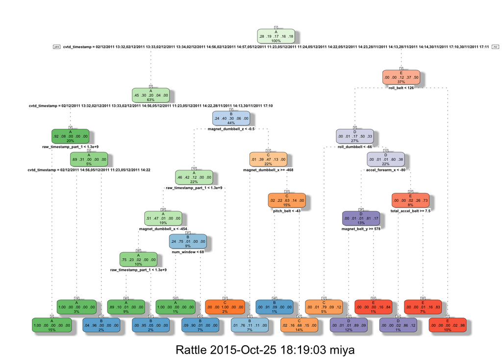

```r
set.seed(32422)
fitDtree = rpart(classe~.,data=training,method="class")
fancyRpartPlot(fitDtree)
```

```r
predDtree = predict(fitDtree,testing,type="class")
confusionMatrix(testing$classe,predDtree)
```

```
## Confusion Matrix and Statistics
##
##           Reference
## Prediction    A    B    C    D    E
##          A 1080   25   11    0    0
##          B   30  638   86    5    0
##          C    3   51  615   11    4
##          D    3   33  104  434   69
##          E    0    0   27   47  647
##
## Overall Statistics
##
##                Accuracy : 0.8703
##                  95% CI : (0.8593, 0.8806)
##     No Information Rate : 0.2845
##     P-Value [Acc > NIR] : < 2.2e-16
##
##                   Kappa : 0.8358
##  Mcnemar's Test P-Value : NA
##
## Statistics by Class:
##
##                      Class: A Class: B Class: C Class: D Class: E
## Sensitivity            0.9677   0.8541   0.7295   0.8732   0.8986
## Specificity            0.9872   0.9619   0.9776   0.9390   0.9769
## Pos Pred Value         0.9677   0.8406   0.8991   0.6750   0.8974
## Neg Pred Value         0.9872   0.9655   0.9296   0.9808   0.9772
## Prevalence             0.2845   0.1904   0.2149   0.1267   0.1835
## Detection Rate         0.2753   0.1626   0.1568   0.1106   0.1649
## Detection Prevalence   0.2845   0.1935   0.1744   0.1639   0.1838
## Balanced Accuracy      0.9775   0.9080   0.8536   0.9061   0.9378
```

### Random Forests

```r
set.seed(32422)
fitRf = randomForest(classe~.,data=training)
predRf = predict(fitRf,testing)
confusionMatrix(testing$classe,predRf)
```

```
## Confusion Matrix and Statistics
##
##           Reference
## Prediction    A    B    C    D    E
##          A 1116    0    0    0    0
##          B    1  758    0    0    0
##          C    0    2  682    0    0
##          D    0    0    4  637    2
##          E    0    0    0    0  721
##
## Overall Statistics
##
##                Accuracy : 0.9977
##                  95% CI : (0.9956, 0.999)
##     No Information Rate : 0.2847
##     P-Value [Acc > NIR] : < 2.2e-16
##
##                   Kappa : 0.9971
##  Mcnemar's Test P-Value : NA
##
## Statistics by Class:
##
##                      Class: A Class: B Class: C Class: D Class: E
## Sensitivity            0.9991   0.9974   0.9942   1.0000   0.9972
## Specificity            1.0000   0.9997   0.9994   0.9982   1.0000
## Pos Pred Value         1.0000   0.9987   0.9971   0.9907   1.0000
## Neg Pred Value         0.9996   0.9994   0.9988   1.0000   0.9994
## Prevalence             0.2847   0.1937   0.1749   0.1624   0.1843
## Detection Rate         0.2845   0.1932   0.1738   0.1624   0.1838
## Detection Prevalence   0.2845   0.1935   0.1744   0.1639   0.1838
## Balanced Accuracy      0.9996   0.9985   0.9968   0.9991   0.9986
```

As we can see, the Random Forest yielded the best performance.

## Expectation for out-of-sample error

```r
predOut = predict(fitRf,validating)
missClass = function(values,prediction){
  sum(prediction!=values)/length(values)
}
errorRate = missClass(validating$classe,predOut)
errorRate
```

```
## [1] 0.001274535
```

## Generating Files to submit

```r
levels(plmTraining$cvtd_timestamp) -> levels(plmTesting$cvtd_timestamp)
pred2 = predict(fitRf,plmTesting)

pml_write_files = function(x){
  n = length(x)
  for(i in 1:n){
    filename = paste0("problem_id_",i,".txt")
    write.table(x[i],file=filename,quote=FALSE,row.names=FALSE,col.names=FALSE)
  }
}


pml_write_files(pred2)
```